# Projekt

Patrycja Milo 173182, Natalia Rozner 173205

20.06.2023

## Pary małżeńskie w USA: spostrzeżenia dotyczące pracy i gospodarstwa domowego

Wczytanie bibliotek

```r
library(ggplot2)
library(dplyr)
library(tidyr)
library(corrplot)
library(graphics)
library(gridExtra)
```

Wczytanie zbioru danych

```r
USA_malzenstwa <- read.csv("./data.txt")
```

Sprawdzenie braków danych

```r
anyNA(USA_malzenstwa)
```

```
## [1] FALSE
```

Wyświetlenie struktury danych

```r
str(USA_malzenstwa)
```

```
## 'data.frame':    753 obs. of  19 variables:
##  $ Lp.       : int  1 2 3 4 5 6 7 8 9 10 ...
##  $ work      : chr  "yes" "yes" "yes" "yes" ...
##  $ hoursw    : int  1610 1656 1980 456 1568 2032 1440 1020 1458 1600 ...
##  $ child6    : int  1 0 1 0 1 0 0 0 0 0 ...
##  $ child618  : int  0 2 3 3 2 0 2 0 2 2 ...
##  $ agew      : int  32 30 35 34 31 54 37 54 48 39 ...
##  $ educw     : int  12 12 12 12 14 12 16 12 12 12 ...
##  $ hearnw    : num  3.35 1.39 4.55 1.1 4.59 ...
##  $ wagew     : num  2.65 2.65 4.04 3.25 3.6 4.7 5.95 9.98 0 4.15 ...
##  $ hoursh    : int  2708 2310 3072 1920 2000 1040 2670 4120 1995 2100 ...
##  $ ageh      : int  34 30 40 53 32 57 37 53 52 43 ...
##  $ educh     : int  12 9 12 10 12 11 12 8 4 12 ...
##  $ wageh     : num  4.03 8.44 3.58 3.54 10 ...
##  $ income    : int  16310 21800 21040 7300 27300 19495 21152 18900 20405 20425 ...
##  $ educwm    : int  12 7 12 7 12 14 14 3 7 7 ...
##  $ educwf    : int  7 7 7 7 14 7 7 3 7 7 ...
##  $ unemprate : num  5 11 5 5 9.5 7.5 5 5 3 5 ...
##  $ city      : chr  "no" "yes" "no" "no" ...
##  $ experience: int  14 5 15 6 7 33 11 35 24 21 ...
```

Usunięcie niepotrzebnej kolumny

```r
data <- data.frame(USA_malzenstwa[,c(-1)])
```

## 1. Przedstawienie ilości osób pracujących w domu w 1975

Zliczanie liczby małżeństw pracujących w domu

```r
(praca_w_domu <- sum(data$work == "yes"))
```

```
## [1] 428
```

Obliczanie procentowego udziału małżeństw pracujących w domu (nrow - zlicza liczbę wierszy, digits = 2 - dwa miejsca po przecinku)

```r
procentowo_praca_w_domu <- round((praca_w_domu / nrow(data)) * 100, digits = 2)
```

Wyświetlanie wyniku

```r
cat("Procent małżeństw pracujących w domu:", procentowo_praca_w_domu, "%\n")
```

```
## Procent małżeństw pracujących w domu: 56.84 %
```

## 2. Porównanie liczby godzin pracy rocznie między mężczyznami a kobietami

Zmienna ta ma powtarzać wartość “Kobieta” i “Mężczyzna” dla odpowiedniej liczby wierszy w ramce danych (razem 1506 rekordów)

```r
płeć <- rep(c("Kobieta", "Mężczyzna"), each = nrow(data))
```

Tworzenie ramki danych dla porównania godzin pracy kobiet i mężczyzn

```r
godziny_pracy_data <- data.frame(Płeć = płeć, Godziny = c(data$hoursw, data$hoursh))
```

Tworzenie wykresu słupkowego, funkcja tapply oblicza średnią liczbę godzin pracy dla każdej płci

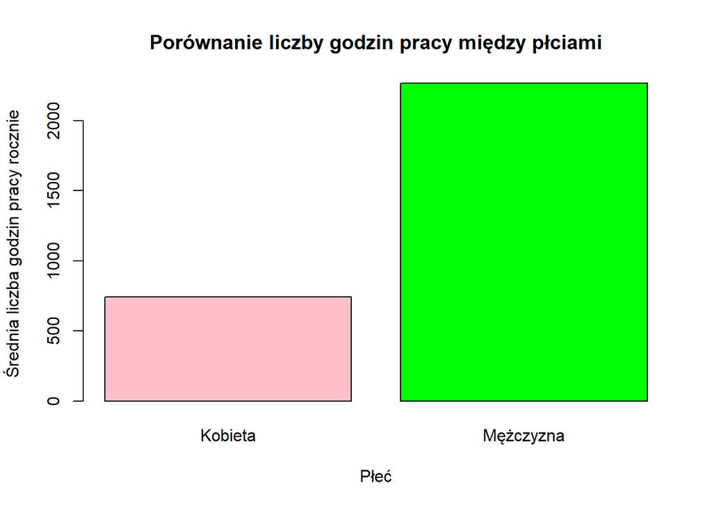

```r
barplot(tapply(godziny_pracy_data$Godziny, godziny_pracy_data$Płeć, mean),
        names.arg = c("Kobieta", "Mężczyzna"),
        xlab = "Płeć", ylab = "Średnia liczba godzin pracy rocznie",
        main = "Porównanie liczby godzin pracy między płciami",
        col = c("pink", "green"))
```

## 3. Dzieci

Obliczanie liczby wszystkich dzieci w gospodarstwie domowym

```r
liczba_dzieci <- data$child6 + data$child618
```

Obliczanie średniej liczby dzieci w gospodarstwie domowym

```r
srednia_dzieci <- round(mean(liczba_dzieci), digits = 2)
```

Obliczanie procentowego udziału gospodarstw domowych z dziećmi

```r
procent_z_dziecmi <- round((sum(liczba_dzieci > 0) / nrow(data)) * 100)
```

Obliczanie najmniejszej i największej liczby dzieci w gospodarstwie domowym

```r
min_dzieci <- min(liczba_dzieci)
max_dzieci <- max(liczba_dzieci)
```

Tworzenie podsumowania

```r
dzieci <- data.frame(
  Srednia_Liczba_Dzieci = srednia_dzieci,
  Procent_Gospodarstw_z_Dziecmi = procent_z_dziecmi,
  Najmniejsza_Liczba_Dzieci = min_dzieci,
  Najwieksza_Liczba_Dzieci = max_dzieci
)
```

Wyświetlanie podsumowania

```r
print(dzieci)
```

```
##   Srednia_Liczba_Dzieci Procent_Gospodarstw_z_Dziecmi Najmniejsza_Liczba_Dzieci
## 1                  1.59                            70                         0
##   Najwieksza_Liczba_Dzieci
## 1                        8
```

## 4. Zależność między poziomem wykształcenia a zarobkami mężczyzn

Porównanie zarobków mężczyzn według poziomu wykształcenia, średnie zarobki (wageh) pogrupowane według poziomu wykształcenia (educh)

```r
agregacja_wyksztalcenie_zarobki <- aggregate(wageh ~ educh, data = data, FUN = mean)
```

Sortowanie poziomów wykształcenia rosnąco według poziomów wykształcenia

```r
agregacja_wyksztalcenie_zarobki <- agregacja_wyksztalcenie_zarobki[order(agregacja_wyksztalcenie_zarobki$educh), ]
```

Tworzenie gradientu kolorystycznego

```r
gradient_kolorow <- colorRampPalette(c("blue", "red"))
```

Obliczanie kolorów dla słupków na podstawie gradientu (liczba kolorów jest równa liczbie poziomów wykształcenia)

```r
kolor_slupek <- gradient_kolorow(length(agregacja_wyksztalcenie_zarobki$wageh))
```

Wykres słupkowy przedstawiający zależność między poziomem wykształcenia a zarobkami mężczyzn Słupki na wykresie reprezentują średnie zarobki na godzinę (wageh) dla poszczególnych poziomów wykształcenia (educh)

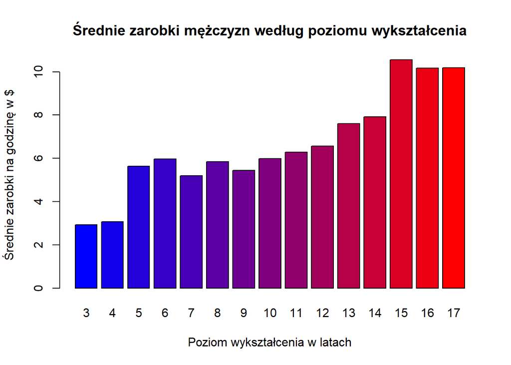

```r
barplot(agregacja_wyksztalcenie_zarobki$wageh, names.arg = agregacja_wyksztalcenie_zarobki$educh,
        xlab = "Poziom wykształcenia w latach", ylab = "Średnie zarobki na godzinę w $",
        main = "Średnie zarobki mężczyzn według poziomu wykształcenia",
        col = kolor_slupek)
```

## 5. Zależność między dochodem rodziny a ilością dzieci

Tworzenie nowej ramki danych z dwoma zmiennymi: dochód rodziny i ilosc dzieci

```r
dochod_i_dzieci <- data.frame(Dochod_Rodziny = data$income, Ilosc_Dzieci = data$child6 + data$child618)
```

Wykres liniowy (geom_smooth: dodanie linii regresji, geom_point: dodanie punktów danych(alpha - przezroczystosc punktow)) lm - liniowa regresja, se = FALSE - bez prawdopobienstwa linii regresji, dzieki czemu wykres jest bardziej przejerzysty)

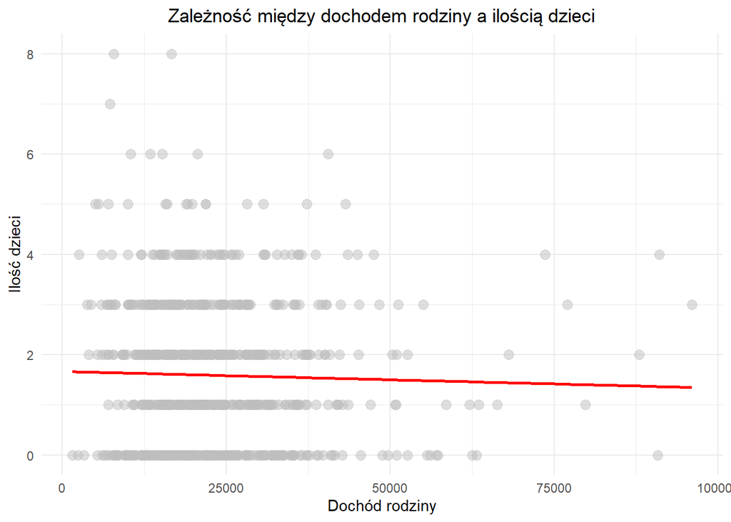

```r
ggplot(dochod_i_dzieci, aes(x = Dochod_Rodziny, y = Ilosc_Dzieci)) +
  geom_smooth(method = "lm", se = FALSE, color = "red") +
  geom_point(color = "gray", size = 3, alpha = 0.5) +
  labs(title = "Zależność między dochodem rodziny a ilością dzieci",
       x = "Dochód rodziny",
       y = "Ilość dzieci") +
  theme_minimal() +
  theme(plot.title = element_text(hjust = 0.5))
```

## 6. Porównanie dochodu kobiet, który został zgłoszony, a który został zarobiony

Tworzenie ramki danych(funkcja factor() konwertuje wektor na czynnik (factor) o nazwie “Rok”) Czynniki są używane w celu reprezentowania zmiennych kategorycznych.)

```r
porownanie_zarobkow <- data.frame(
  Rok = factor(c(rep("1975", nrow(data)), rep("1976", nrow(data)))),
  Zarobki = c(data$hearnw, data$wagew))
```

Wykres

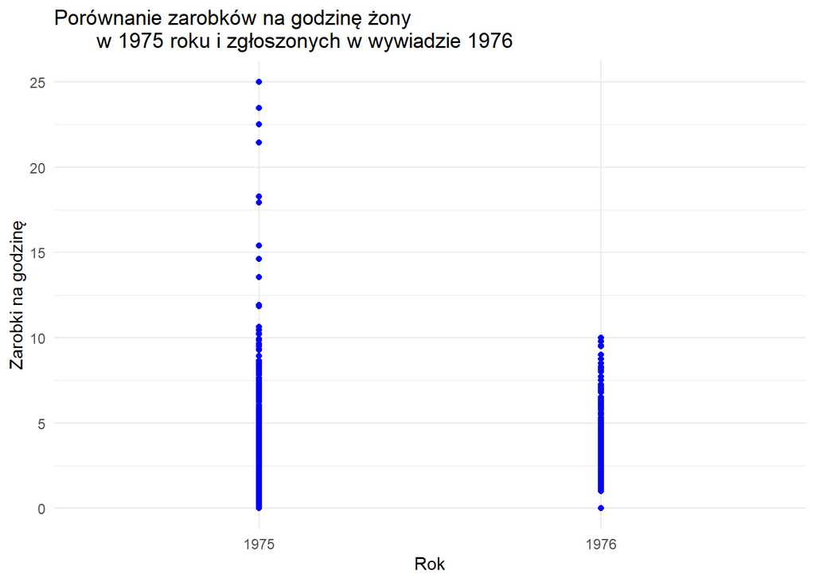

```r
ggplot(porownanie_zarobkow, aes(x = Rok, y = Zarobki)) +
  geom_point(color = "blue") +
  labs(title = "Porównanie zarobków na godzinę żony
       w 1975 roku i zgłoszonych w wywiadzie 1976",
       x = "Rok",
       y = "Zarobki na godzinę") +
  theme_minimal()
```

## 7. Obliczanie procentu rodzin w najgorszych wynikach zarobków

```r
procentyl = quantile(data$income, 0.1)
```

Dochód jest mniejszy lub równy wartości procentylu

```r
ubostwo <- subset(data, income <= procentyl)
```

Wykres - liczba dzieci

```r
wykres_dzieci <- ggplot(ubostwo, aes(x = "", fill = factor(child6 + child618))) +
  geom_bar(width = 1, color = "white") +
  coord_polar("y") +
  labs(title = "Liczba dzieci w rodzinach
       w ubóstwie",
       fill = "Liczba dzieci",
       x = "") +
  theme_void()
```

Wykres - miejsce zamieszkania

```r
wykres_lokalizacja <- ggplot(ubostwo, aes(x = "", fill = city)) +
  geom_bar(width = 1, color = "white") +
  coord_polar("y") +
  labs(title = "Lokalizacja rodzin w ubóstwie",
       fill = "Miasto",
       x = "") +
  theme_void() +
  geom_text(aes(label = scales::percent(..count../sum(..count..))), stat = "count", position = position_stack(vjust = 0.5))
```

Wykres - wiek matki

```r
wykres_wiek_matki <- ggplot(ubostwo, aes(x = "", fill = cut(agew, breaks = c(0, 20, 30, 40, 50, 60, Inf)))) +
  geom_bar(width = 1, color = "white") +
  coord_polar("y") +
  labs(title = "Wiek matki w rodzinach
       w ubóstwie",
       fill = "Wiek matki",
       x = "") +
  theme_void() +
  geom_text(aes(label = scales::percent(..count../sum(..count..))), stat = "count", position = position_stack(vjust = 0.5))
```

Wykres - wiek ojca

```r
wykres_wiek_ojca <- ggplot(ubostwo, aes(x = "", fill = cut(ageh, breaks = c(0, 20, 30, 40, 50, 60, Inf)))) +
  geom_bar(width = 1, color = "white") +
  coord_polar("y") +
  labs(title = "Wiek ojca w rodzinach w ubóstwie",
       fill = "Wiek ojca",
       x = "") +
  theme_void() +
  geom_text(aes(label = scales::percent(..count../sum(..count..))), stat = "count", position = position_stack(vjust = 0.5))
```

Wyświetlanie wykresów w jednym oknie (wykresy kolowe)

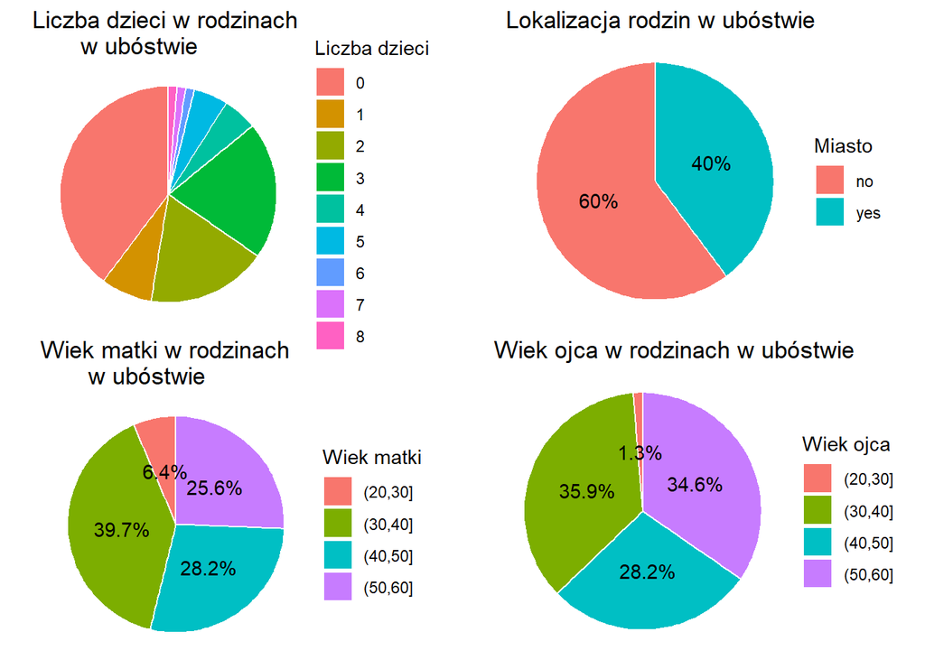

```r
grid.arrange(wykres_dzieci, wykres_lokalizacja, wykres_wiek_matki, wykres_wiek_ojca,
             ncol = 2, widths = c(1, 1), heights = c(1, 1))
```

## 8. Analiza rodzin z dziećmi i bez

Analiza dla rodzin z dziećmi

```r
df_z_dziecmi <- subset(data, child6 + child618 > 0)
```

Wykres - wykształcenie matki

```r
wykres_wyksztalcenie_matki <- ggplot(df_z_dziecmi, aes(x = educwm)) +
  geom_bar(fill = "red") +
  labs(title =
         "Wykształcenie matki
       w rodzinach z dziećmi",
       x = "Wykształcenie matki",
       y = "Ilość osób") +
  theme_minimal()
```

Wykres - wykształcenie ojca

```r
wykres_wyksztalcenie_ojca <- ggplot(df_z_dziecmi, aes(x = educwf)) +
  geom_bar(fill = "green") +
  labs(title =
        "Wykształcenie ojca
       w rodzinach z dziećmi",
       x = "Wykształcenie ojca",
       y = "Ilość osób") +
  theme_minimal()
```

Analiza dla rodzin bez dzieci

```r
df_bez_dzieci <- subset(data, child6 + child618 == 0)
```

Wykres - wykształcenie żony

```r
wykres_wyksztalcenie_zony <- ggplot(df_bez_dzieci, aes(x = educw)) +
  geom_bar(fill = "pink") +
  labs(title =
        "Wykształcenie żony
       w rodzinach bez dzieci ",
       x = "Wykształcenie żony",
       y = "Ilość osób") +
  theme_minimal()
```

Wykres - wykształcenie męża

```r
wykres_wyksztalcenie_męża <- ggplot(df_bez_dzieci, aes(x = educh)) +
  geom_bar(fill = "blue") +
  labs(title =
        "Wykształcenie męża
       w rodzinach bez dzieci",
       x = "Wykształcenie męża",
       y = "Ilość osób") +
  theme_minimal()
```

Wyświetlanie wykresów w jednym oknie

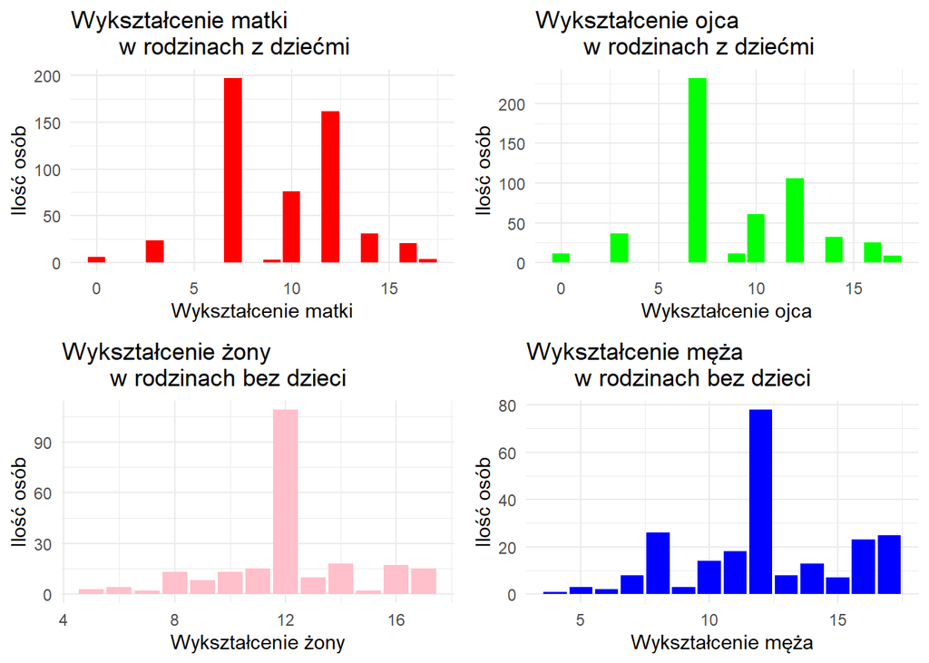

```r
grid.arrange(wykres_wyksztalcenie_matki, wykres_wyksztalcenie_ojca, wykres_wyksztalcenie_zony, wykres_wyksztalcenie_męża,
             ncol = 2, widths = c(1, 1), heights = c(1, 1))
```